Introduction:

This project intends to provide some more insight about the distribution of the restaurants, their prices, their customer satisfactions and their popularities based on the data extracted from www.yelp.com the biggest repository for restaurants information website. To obtain the data, a web scrapter is written to automatically extract all the data. Moreover, to obtain the population and salary data associated with the zipcodes, we used the data provided by Population Study Center from university of michigan . Data is provided as xlsx data file in the following website: “http://www.psc.isr.umich.edu/dis/census/Features/tract2zip/”

13474 restaurants are recorded in 15 major cities in united states with 546 unique zip codes associated with them. :

The cities are:

“New York,NY”,“Chicago,IL”,“Boston,MA”,“Los Angeles,CA”,“Houston,TX”,“Philadelphia,PA”,“San Francisco,CA”,“Houston,TX”,“Washington ,DC”,“Phoenix,AZ”,“Seattle,WA”,“Baltimore,MD”,“Cleaveland,OH”,“Las Vegas,NV”,“Austin,TX”

It is aimed to perform regression analysis to find direct or indirect significant linear relationships between independent parameters like price , satisfaction , wealth of people, popularity of restaurants and so on.

And finally some prediction studies using machine learning techniques like “supervised learning” has been done.

```r
#################################################################################################



cat("\014")    #This clears the Consol
rm(list=ls())    #This removes all the variables previously existed in Global Environment.
require(RCurl)    #Downloading Package
require(XML)
library(RCurl)     #Using package in this program
library(XML)
library(stringr)
#Set the working directory to your workspace
setwd("C:/Users/monabiyan/SkyDrive/Summer 2015/Collect,retrieve data/Week14(Term-Project)")

#YelpParse Function parses data in the YELP search pages. It provides Name,Type,Price, the number of reviews and the Tell number for each element.
#The Elements could be restaurant or bars or coffee-shops or so many other places.
#It is requiered to find the link in YELP website and put it in the YelpParse function here.
#User is able to choose which information he/she wants as output by putting TRUE or FALSE in the correponding places for input.
#TYPE,PRICE,REVIEW,TELL should be substituted by TRUE or FALSE based on User's need.
YelpParse<-function(link)
{

  ########## To understand which information the user wants######
  #choice=0;
  #choice[1]=1
  #choice[2]=as.numeric(TYPE)*2
  #choice[3]=as.numeric(PRICE)*3
  #choice[4]=as.numeric(REVIEW)*4
  #choice[5]=as.numeric(TELL)*5
  ################################################################
  # This is the URL of the website we need scrape to get information on the

  theurl <- link
  theurl<-gsub(" ","",theurl);   #No extra spaces
  webpage <- getURL(theurl)
  # convert the page into a line-by-line format rather than a single string
  tc <- textConnection(webpage)
  webpage <- readLines(tc) #webpage is now a vector of string each elament is a line of string
  close(tc)
  pagetree <- htmlTreeParse(webpage, useInternalNodes = TRUE)  #pagetree is now in html format and parseable with xpath syntax.



  #########################  NAME  ###############################

  restaurant.name<- unlist(xpathApply(pagetree,"//*/span[@class='indexed-biz-name']/a[@*][@*][@*]",xmlValue))
  if(length(restaurant.name)==11)   #Sometimes it gives 11 ellements and the first one is wrong"
  {restaurant.name<-restaurant.name[2:11]}
  restaurant.name<-as.character(restaurant.name)
  restaurant.name<-gsub("<U+0092>","",restaurant.name)

     ###### Removing <U+0092> ####  I Found this in Internet
  Encoding(restaurant.name) <- "latin1"  # (just to make sure)
  iconv(restaurant.name, "latin1", "ASCII", sub="")
     #####


  restaurant.name



  ############################   REVIEW COUNT  #############################

  review.count<-unlist(xpathApply(pagetree,"//*/span[@class='review-count rating-qualifier']",xmlValue))
  review.count
  review.count<-gsub("\n            ", "",review.count) #Removing extra characters"
  review.count<-gsub("\n    ", "",review.count)
  review.count<-gsub(" reviews", "",review.count)
  if(length(review.count)==11)
  {review.count<-review.count[2:11]}
  review.count<-as.numeric(review.count)
  review.count

  ############################# PRICE #############################

  restaurant.price<-unlist(xpathApply(pagetree,"//*/span[@class='business-attribute price-range']",xmlValue))
  print(restaurant.price)
  for (i in 1:length(restaurant.price))     #Scaling price notations to 1,2,3,4 accordingly where 4 is very epensive.
  {
    if (restaurant.price[i]=="$")  {restaurant.price[i]="1"; }
    if (restaurant.price[i]=="$$")  {restaurant.price[i]="2"; }
    if (restaurant.price[i]=="$$$")  {restaurant.price[i]="3"; }
    if (restaurant.price[i]=="$$$$")  {restaurant.price[i]="4"; }
  }
  restaurant.price
  if(length(restaurant.price)==11)
  {restaurant.price<-restaurant.price[2:11]}
  restaurant.price<-as.numeric(restaurant.price)
  restaurant.price


  #########################  TYPE   ############################

  restaurant.type<-unlist(xpathApply(pagetree,"//*/span[@class='category-str-list']/a[@*][1]",xmlValue))  ##Some times there are several <a> tags. We need the first one.
  if(length(restaurant.type)==11)
  {restaurant.type<-restaurant.type[2:11]}
  restaurant.type<-as.character(restaurant.type)
  restaurant.type

  ########################   star  ###############################
  restaurant.star<-unlist(xpathApply(pagetree,"//*/div[@class='rating-large']/i",xmlAttrs))
  restaurant.star<-as.character(restaurant.star)

  restaurant.star<-gsub(" star rating", "",restaurant.star)
  hh=0;
  for (i in 1:(length(restaurant.star)/2))
  {hh[i]<-restaurant.star[2*i]}
  restaurant.star<-hh
  restaurant.star<-as.numeric(restaurant.star)



  ########################   Neighborhood  ###############################
  restaurant.neighborhood<-unlist(xpathApply(pagetree,"//*/span[@class='neighborhood-str-list']",xmlValue))

  restaurant.neighborhood<-gsub("\n            ", "",restaurant.neighborhood)
  restaurant.neighborhood<-gsub("        ", "",restaurant.neighborhood)
  if(length(restaurant.neighborhood)==11)
  {restaurant.neighborhood<-restaurant.neighborhood[2:11]}
  restaurant.neighborhood<-as.character(restaurant.neighborhood)
  restaurant.neighborhood


  ########################   ADDRESS  ###############################
  restaurant.address<-unlist(xpathApply(pagetree,"//*/address",xmlValue))

  restaurant.address<-gsub("\n            ", "",restaurant.address)
  restaurant.address<-gsub("        ", "",restaurant.address)
  restaurant.address<-gsub("\n", "",restaurant.address)
  restaurant.address<-gsub(city,paste(" ",city),restaurant.address)
  if(length(restaurant.address)==11)
  {restaurant.address<-restaurant.address[2:11]}
  restaurant.address<-as.character(restaurant.address)
  restaurant.address
  restaurant.zip<-str_sub(restaurant.address,-5,-1)
  ############################  TELL  ##############################

  restaurant.tell<-unlist(xpathApply(pagetree,"//*/div[@class='secondary-attributes']/span[@class='biz-phone']",xmlValue))
  restaurant.tell<-gsub("\n        ", "",restaurant.tell)
  restaurant.tell<-gsub("\n    ", "",restaurant.tell)
  if(length(restaurant.tell)==11)
  {restaurant.tell<-restaurant.tell[2:11]}
  restaurant.tell<-as.character(restaurant.tell)
  restaurant.tell
```

```r
  ############################### Putting ALL in a DATA FRAME ##############################
  min_length=min(length(restaurant.name),length(restaurant.type),length(restaurant.price),length(review.count),length(restaurant.tell),length(restaurant.address),length(restaurant.star))
  restaurant.data<-data.frame(NAME=restaurant.name[1:min_length],TYPE=restaurant.type[1:min_length],PRICE= restaurant.price[1:min_length],REVIEW_COUNT=review.count[1:min_length],STAR=restaurant.star[1:min_length],TELL=restaurant.tell[1:min_length],ADDRESS=restaurant.address[1:min_length],ZIPCODE=restaurant.zip[1:min_length])
  return(restaurant.data)
}

  ##################Statistical and Searching Questions   ###############

  #print(restaurant.data[,choice])
  #print(paste("The average price levels is",mean(restaurant.data$PRICE)))
  #print(paste("The standard deviation of price levels is",sd(restaurant.data$PRICE)))
  #print(paste("The average number of reviews for restaurant is",mean(restaurant.data$REVIEW_COUNT) ))
  #print(paste(restaurant.data$NAME[restaurant.data$PRICE==1],"  is inexpensive. ENJOY!!"))


  #####################  Examples of Using the function#################




########################################  Finding Geographical Coordinates Using Google API
##Google API and use of static map
## Author - Martin Schedlbauer and Yatish Jain
## Version 1.1

library(RCurl)
library(RJSONIO)
library(plyr)

#getLocation function returns the latitude and longitude of any address via google maps api.

#fetchUrl function gives the url to fetch json string.
fetchUrl <- function(address)
  {
    root <- "http://maps.google.com/maps/api/geocode/"   #root url
    u <- paste(root, "json", "?address=", address, "&sensor=false", sep = "")
    return(URLencode(u)) #encoding the url
  }





getLocation <- function(address)
  {
    url <- fetchUrl(address) #getting the url for the address, I suggest to take a look at this URL before further exploring the code.
    json <- getURL(url)
    x <- fromJSON(json,simplify = FALSE) #getting the json
    if(x$status=="OK") { #checking if the Address url used produces the correct json string
    lat <- x$results[[1]]$geometry$location$lat
    lng <- x$results[[1]]$geometry$location$lng
    location_type <- x$results[[1]]$geometry$location_type
    formatted_address <- x$results[[1]]$formatted_address
    return(c(lat, lng, location_type, formatted_address))
    Sys.sleep(0.5)
  } else {
    return(c(NA,NA,NA,NA))
  }
}



AddSalary<-function(df)
{
  zip_info<-read.csv("MedianZIP-3.csv",header=TRUE,stringsAsFactors=FALSE)


  zip_info$Zip<-as.character(zip_info$Zip)
  for (i in 1:length(zip_info[,1]))
  {
    if(nchar(zip_info$Zip[i])==4)
    {
      zip_info$Zip[i]<-paste("0",zip_info$Zip[i])
    }
  }
  zip_info$Zip<-gsub(" ", "",zip_info$Zip)


  zip_info$Median<-as.character(zip_info$Median)
  zip_info$Mean<-as.character(zip_info$Mean)
  zip_info$Pop<-as.character(zip_info$Pop)
  df$ZIPCODE<-as.character(df$ZIPCODE)


  MEDIAN_SAL<-0;
  MEAN_SAL<-0;
  POP<-0;



  for(i in 1:length(df[,1]))
  {
    if (sum(df$ZIPCODE[i]==zip_info$Zip)==0)
    {
      MEDIAN_SAL[i]=0;
      MEAN_SAL[i]=0;
      POP[i]=0;
    }
    else
    {
      MEDIAN_SAL[i]<-zip_info$Median[df$ZIPCODE[i]==zip_info$Zip]
      MEAN_SAL[i]<-zip_info$Mean[df$ZIPCODE[i]==zip_info$Zip]
      POP[i]<-zip_info$Pop[df$ZIPCODE[i]==zip_info$Zip]
    }
  }
  df<-cbind(df,MEDIAN_SAL,MEAN_SAL,POP)
  return(df)

}





##############################################################

setwd("C:/Users/nabian.m/Desktop/cities")


megacities<-c("New York,NY","Chicago,IL","Boston,MA","Los Angeles,CA","Houston,TX","Philadelphia,PA","San Francisco,CA","Houston,TX","Washington ,DC","Phoenix,AZ","Seattle,WA","Baltimore,MD","Cleaveland,OH","Las Vegas,NV","Austin,TX","Oklahama City,OK")

n<-90

for (location in megacities)
{
      print(location)
      comma<-unlist(str_locate_all(pattern =',',location))[1]
      comma<-as.numeric(comma)
      city<-str_sub(location,start=1,end=(comma-1))
      state<-str_sub(location,start=(comma+1),end=nchar(location))
      print(city)
      address<-paste("http://www.yelp.com/search?find_desc=Restaurants&find_loc=",city,"%2C+",state,"&start=",as.character(0),sep="")
      all<-YelpParse(address)

      print(all)

      #ads <- all$ADDRESS
      #locations <- ldply(ads, function(x) getLocation(x))
      #names(locations) <- c("LATTITUDE", "LONGITUDE", "location_type", "formatted")
      #all<-cbind(all,locations)



      for (i in 1:n)
      {
        print(i)
        address<-paste("http://www.yelp.com/search?find_desc=Restaurants&find_loc=",city,"%2C+",state,"&start=",as.character(i*10),sep="")
        df<-YelpParse(address)

        #ads <- df$ADDRESS
        #locations <- ldply(address, function(x) getLocation(x))
        #names(locations) <- c("LATTITUDE", "LONGITUDE", "location_type", "formatted")

        #hh<-cbind(df,locations)
        #all<-rbind(all,hh)
        all<-rbind(all,df)
      }



      all<-AddSalary(all)  #Update with the salaries and populations
      all<cbind(all,city)
      all<-all[-which((all$POP==0)==TRUE),]
      head(all)

      write.csv(all,file=paste(city,"_res.csv"),row.names = FALSE)

}


#########################################################################


######################### Adding City as a new column ###############

setwd("C:/Users/nabian.m/Desktop/cities")
megacities<-c("New York,NY","Chicago,IL","Boston,MA","Los Angeles,CA","Houston,TX","Philadelphia,PA","San Francisco,CA","Houston,TX","Washington ,DC","Phoenix,AZ","Seattle,WA","Baltimore,MD","Cleaveland,OH","Las Vegas,NV","Austin,TX","Oklahama City,OK")

for (location in megacity)
{
  print(location)
  comma<-unlist(str_locate_all(pattern =',',location))[1]
  comma<-as.numeric(comma)
  city<-str_sub(location,start=1,end=(comma-1))
  state<-str_sub(location,start=(comma+1),end=nchar(location))


  all<-read.csv(file=paste(city,"_res.csv"))
  all<-cbind(all,city)
  write.csv(all,file=paste(city,"_res.csv"),row.names = FALSE)
}
```

```r
###############################################################


############ earasing comma "," from Salary and Population ####

setwd("C:/Users/nabian.m/Desktop/cities")
megacities<-c("New York,NY","Chicago,IL","Boston,MA","Los Angeles,CA","Houston,TX","Philadelphia,PA","San Francisco,CA","Houston,TX","Washington ,DC","Phoenix,AZ","Seattle,WA","Baltimore,MD","Cleaveland,OH","Las Vegas,NV","Austin,TX","Oklahama City,OK")

for (location in megacities)
{
  print(location)
  comma<-unlist(str_locate_all(pattern =',',location))[1]
  comma<-as.numeric(comma)
  city<-str_sub(location,start=1,end=(comma-1))
  state<-str_sub(location,start=(comma+1),end=nchar(location))


  all<-read.csv(file=paste(city,"_res.csv"))

  all$MEDIAN_SAL<-gsub(",","",all$MEDIAN_SAL)
  all$MEAN_SAL<-gsub(",","",all$MEAN_SAL)
  all$POP<-gsub(",","",all$POP)

  write.csv(all,file=paste(city,"_res.csv"),row.names = FALSE)
}


########################################################
```

So far all requiered data are collected and saved in csv files. Each city one file.

Now lets start reading the data:

```r
########### Reading and Making One DataFarme of All Files ############################################


library(stringr)
setwd("C:/Users/nabian.m/Desktop/cities")
megacity<-"New York,NY"

for (location in megacity)
{
  print(location)
  comma<-unlist(str_locate_all(pattern =',',location))[1]
  comma<-as.numeric(comma)
  city<-str_sub(location,start=1,end=(comma-1))
  state<-str_sub(location,start=(comma+1),end=nchar(location))


  all<-read.csv(file=paste(city,"_res.csv"))
}
```

```
## [1] "New York,NY"
```

```r
megacities<-c("Chicago,IL","Boston,MA","Los Angeles,CA","Houston,TX","Philadelphia,PA","San Francisco,CA","Houston,TX","Washington ,DC","Phoenix,AZ","Seattle,WA","Baltimore,MD","Cleaveland,OH","Las Vegas,NV","Austin,TX","Oklahama City,OK")


for (location in megacities)
{

  comma<-unlist(str_locate_all(pattern =',',location))[1]
  comma<-as.numeric(comma)
  city<-str_sub(location,start=1,end=(comma-1))
  state<-str_sub(location,start=(comma+1),end=nchar(location))
  print(location)
  df<-read.csv(file=paste(city,"_res.csv"))
  all<-rbind(df,all)
}
```

```
## [1] "Chicago,IL"
## [1] "Boston,MA"
## [1] "Los Angeles,CA"
## [1] "Houston,TX"
## [1] "Philadelphia,PA"
## [1] "San Francisco,CA"
## [1] "Houston,TX"
## [1] "Washington ,DC"
## [1] "Phoenix,AZ"
## [1] "Seattle,WA"
## [1] "Baltimore,MD"
## [1] "Cleaveland,OH"
## [1] "Las Vegas,NV"
## [1] "Austin,TX"
## [1] "Oklahama City,OK"
```

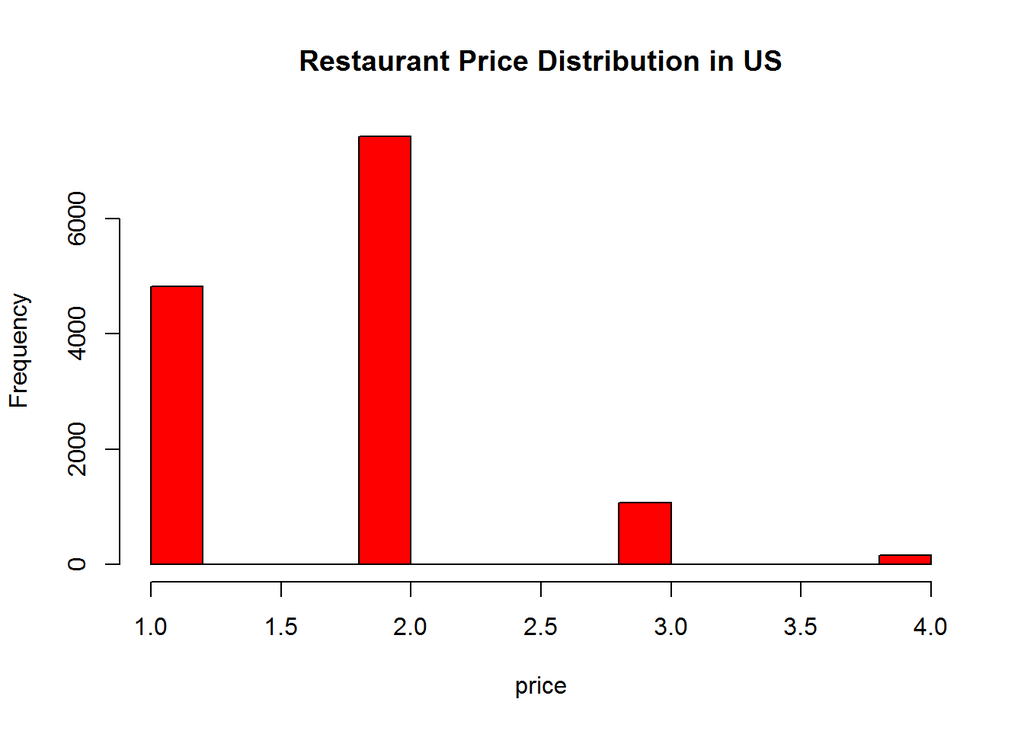

```r
#####################################################




####################  Doing Some Statistical Analysis on 'all' dataframe #############################

#price distribution
hist(all$PRICE,breaks=20, col="red",xlab="price",main="Restaurant Price Distribution in US")
```

```r
#Restaurants Type
tp<-as.data.frame(table(as.factor(all$TYPE)))
tp<-tp[with(tp, order(-tp$Freq)), ]  # sorting restaurant types based of frequency
tp[1:20,]
```

```
##                      Var1 Freq
## 2          American (New) 1305
## 35                Mexican  938
## 29                Italian  757
## 37                  Pizza  698
## 3  American (Traditional)  582
## 40             Sandwiches  414
## 15                Chinese  398
## 7                    Bars  389
## 11                Burgers  384
## 41                Seafood  365
## 30               Japanese  317
## 48                   Thai  313
## 10     Breakfast & Brunch  297
## 17           Coffee & Tea  282
## 49             Vietnamese  271
## 12                  Cafes  241
## 61                  Delis  241
## 76                 Korean  225
## 70                 French  222
## 34          Mediterranean  214
```

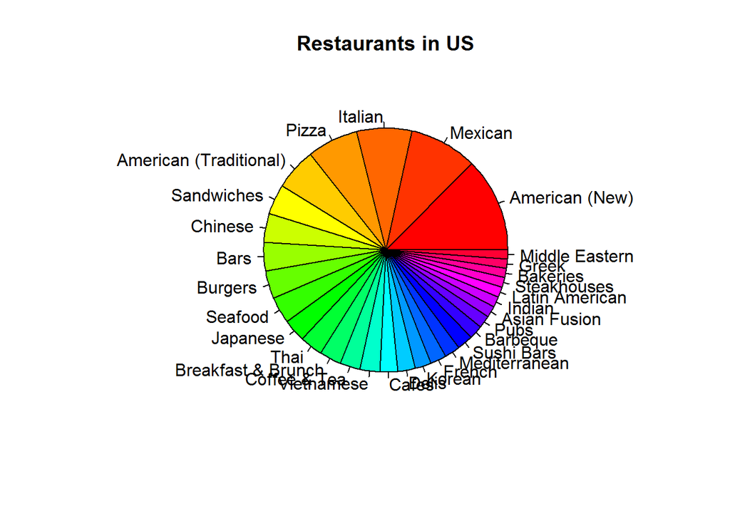

```r
pie(tp$Freq[1:30], labels = tp$Var1[1:30], main="Restaurants in US",col=rainbow(30))
```

```r
######## For Each city Medians and Means


megacities<-c("New York,NY","Chicago,IL","Boston,MA","Los Angeles,CA","Houston,TX","Philadelphia,PA","San Francisco,CA","Houston,TX","Washington ,DC","Phoenix,AZ","Seattle,WA","Baltimore,MD","Cleaveland,OH","Las Vegas,NV","Austin,TX")

i=1;
median_price=0;
mean_price=0;
median_reviews=0;
mean_reviews=0;
median_star=0;
mean_star=0;
mean_of_median_salary=0;
population=0;
city_name=0;

for (location in megacities)
{
  comma<-unlist(str_locate_all(pattern =',',location))[1]
  comma<-as.numeric(comma)
  city<-str_sub(location,start=1,end=(comma-1))
  print(city)
  state<-str_sub(location,start=(comma+1),end=nchar(location))


  median_price[i]<-median(as.numeric((all$PRICE[all$city==city])),na.rm = TRUE)

  mean_price[i]<-mean(as.numeric((all$PRICE[all$city==city])),na.rm = TRUE)

  median_reviews[i]<-median(as.numeric((all$REVIEW_COUNT[all$city==city])),na.rm = TRUE)
  mean_reviews[i]<-mean(as.numeric((all$REVIEW_COUNT[all$city==city])),na.rm = TRUE)

  median_star[i]<-median(as.numeric((all$STAR[all$city==city])),na.rm = TRUE)
  mean_star[i]<-mean(as.numeric((all$STAR[all$city==city])),na.rm = TRUE)

  mean_of_median_salary[i]<-median(as.numeric((all$MEDIAN_SAL[all$city==city])),na.rm = TRUE)

  population[i]<-sum(as.numeric((all$POP[all$city==city])),na.rm = TRUE)

  city_name[i]<-city
  i=i+1
}
```

```
## [1] "New York"
## [1] "Chicago"
## [1] "Boston"
## [1] "Los Angeles"
## [1] "Houston"
## [1] "Philadelphia"
## [1] "San Francisco"
## [1] "Houston"
## [1] "Washington "
## [1] "Phoenix"
## [1] "Seattle"
## [1] "Baltimore"
## [1] "Cleaveland"
## [1] "Las Vegas"
## [1] "Austin"
```

Here are the the independent variables for each city:

```r
median_price
```

```
##  [1] 2 2 2 2 2 2 2 2 2 2 2 2 2 2 1
```

```r
mean_price
```

```
##  [1] 1.980877 1.828194 1.743274 1.744469 1.738069 1.739421 1.813877
##  [8] 1.738069 1.874580 1.547991 1.791160 1.684770 1.585642 1.824834
## [15] 1.537264
```

```r
median_reviews
```

```
##  [1] 247.0 222.0 126.0 291.0 124.0 134.5 412.0 124.0 178.0  88.0 183.0
## [12]  41.0  27.0 186.0 170.0
```

```r
mean_reviews
```

```
##  [1] 451.16535 377.31608 211.02130 497.59735 177.42064 211.16147 646.31057
##  [8] 177.42064 270.64054 145.73884 296.07845  85.46368  55.85073 326.19734
## [15] 237.16352
```

```r
median_star
```

```
##  [1] 4.0 4.0 3.5 4.0 4.0 4.0 4.0 4.0 4.0 4.0 4.0 4.0 4.0 4.0 4.0
```

```r
mean_star
```

```
##  [1] 4.120360 4.024780 3.721973 4.046460 3.824084 3.912584 3.996696
##  [8] 3.824084 3.768197 3.917411 3.931492 3.793388 3.764484 4.031042
## [15] 3.980534
```

```r
mean_of_median_salary
```

```
##  [1] 73075 68426 61807 40973 64545 41800 75106 64545 68051 44596 57971
## [12] 48519 30283 42954 47497
```

```r
population
```

```
##  [1] 39070915 45725683 13703325 33130490 47196306 23527972 33151152
##  [8] 47196306 23817566 26551511 22966908 22517160 22586851 27006361
## [15] 24191203
```

```r
city_name
```

```
##  [1] "New York"      "Chicago"       "Boston"        "Los Angeles"
##  [5] "Houston"       "Philadelphia"  "San Francisco" "Houston"
##  [9] "Washington "   "Phoenix"       "Seattle"       "Baltimore"
## [13] "Cleaveland"    "Las Vegas"     "Austin"
```

saving data:

```r
city_info<-data.frame(city_name,mean_price,median_price,median_reviews,mean_reviews,median_star,mean_star,
                    mean_of_median_salary,population)

city_info
```

```
##        city_name mean_price median_price median_reviews mean_reviews
## 1       New York   1.980877            2          247.0    451.16535
## 2        Chicago   1.828194            2          222.0    377.31608
## 3         Boston   1.743274            2          126.0    211.02130
## 4    Los Angeles   1.744469            2          291.0    497.59735
## 5        Houston   1.738069            2          124.0    177.42064
## 6   Philadelphia   1.739421            2          134.5    211.16147
## 7  San Francisco   1.813877            2          412.0    646.31057
## 8        Houston   1.738069            2          124.0    177.42064
## 9    Washington    1.874580            2          178.0    270.64054
## 10       Phoenix   1.547991            2           88.0    145.73884
## 11       Seattle   1.791160            2          183.0    296.07845
## 12     Baltimore   1.684770            2           41.0     85.46368
## 13    Cleaveland   1.585642            2           27.0     55.85073
## 14     Las Vegas   1.824834            2          186.0    326.19734
```

[output cut: 17 more lines]

Now it is time to do analysis based on zip codes.

```r
######## For Each zip Code Medians and Means


i=1;
median_price=0;
mean_price=0;
median_reviews=0;
mean_reviews=0;
median_star=0;
mean_star=0;
median_salary=0;
population=0;
city_name=0;
zip_code=0;
zip_count=0;
for (zip in unique(all$ZIPCODE))
{

  median_price[i]<-median(as.numeric((all$PRICE[all$ZIPCODE==zip])),na.rm = TRUE)

  mean_price[i]<-mean(as.numeric((all$PRICE[all$ZIPCODE==zip])),na.rm = TRUE)

  median_reviews[i]<-median(as.numeric((all$REVIEW_COUNT[all$ZIPCODE==zip])),na.rm = TRUE)
  mean_reviews[i]<-mean(as.numeric((all$REVIEW_COUNT[all$ZIPCODE==zip])),na.rm = TRUE)

  median_star[i]<-median(as.numeric((all$STAR[all$ZIPCODE==zip])),na.rm = TRUE)
  mean_star[i]<-mean(as.numeric((all$STAR[all$ZIPCODE==zip])),na.rm = TRUE)

  median_salary[i]<-as.numeric((all$MEDIAN_SAL[all$ZIPCODE==zip]))

  median_salary[i]<-as.numeric((all$MEDIAN_SAL[all$ZIPCODE==zip]))

  population[i]<-as.numeric((all$POP[all$ZIPCODE==zip]))

  city_name[i]<-as.character(all$city[all$ZIPCODE==zip])

  zip_code[i]<-zip

  zip_count[i]<-sum(all$ZIPCODE==zip)
  i=i+1

}
head(mean_price)
```

```
## [1] 1.863636 2.100000 1.500000 1.692308 2.000000 1.500000
```

```r
head(median_reviews)
```

```
## [1] 87.5 67.5 69.0 81.0 72.0 49.5
```

```r
head(mean_reviews)
```

```
## [1]  96.50000  84.30000 148.00000 107.84615  99.64706  84.16667
```

```r
head(median_star)
```

```
## [1] 4.00 4.00 4.25 4.00 4.00 4.00
```

```r
head(mean_star)
```

```
## [1] 3.886364 3.900000 4.375000 3.923077 4.088235 4.000000
```

```r
head(median_salary)
```

```
## [1] 48692 66665 25482 33739 35294 37011
```

```r
head(population)
```

```
## [1]  4345 10049 15181 13850  3362 24959
```

```r
head(city_name)
```

```
## [1] "Oklahama City" "Oklahama City" "Oklahama City" "Oklahama City"
## [5] "Oklahama City" "Oklahama City"
```

```r
head(zip_code)
```

```
## [1] 73103 73116 73108 73106 73102 73107
```

```r
head(zip_count)
```

```
## [1] 22 10  4 13 17  6
```

Regression Analysis:

Since our analysis is based on zip codes, we only take zipcodes with more than 30 restaurants captured in that zipcode.

```r
zip_info<-data.frame(zip_code,city_name,mean_price,median_price,median_reviews,mean_reviews,median_star,mean_star,median_salary,population,zip_count)

zip_credit<-zip_info[zip_info$zip_count>30,]  # Zip codes that have more than 50 restaurants

head(zip_credit)
```

```
##    zip_code city_name mean_price median_price median_reviews mean_reviews
## 25    78705    Austin   1.426230            1          151.0     213.5574
## 26    78704    Austin   1.504065            1          218.0     342.4553
## 29    78757    Austin   1.541667            1          167.0     245.4583
## 30    78702    Austin   1.552632            1          148.5     221.1053
## 31    78701    Austin   1.712000            2          174.0     270.4960
## 32    78759    Austin   1.694444            2          215.0     261.0833
##    median_star mean_star median_salary population zip_count
## 25           4  3.934426         14590      31340        61
## 26           4  3.983740         47497      42117       123
## 29           4  3.947917         53358      21310        48
## 30           4  4.125000         31715      21334        76
## 31           4  4.016000         65353       6841       125
## 32           4  3.861111         73831      37767        36
```

```r
sum(zip_credit$zip_count)    #9863 restaurants from 154 zipcodes in which 30 restaurants are there
```

```
## [1] 9863
```

```r
#################################################
```

So here are a great information about the zip codes :

```r
############ Highest Score average score for zip codes ######
zip_credit$zip_code[sort(zip_credit$mean_star,decreasing = TRUE)==zip_credit$mean_star]
```

```
## [1] 85020
```

```r
zip_mean_star_ordered<-zip_credit[order(-zip_credit$mean_star),]
```

Highest satisfaction (highest star score) :

```r
head(zip_mean_star_ordered)
```

```
##     zip_code   city_name mean_price median_price median_reviews
## 485    10013    New York   1.958333            2          358.5
## 481    11211    New York   2.021739            2          242.0
## 65     89101   Las Vegas   1.760000            2          218.0
## 482    10002    New York   1.576271            2          192.0
## 30     78702      Austin   1.552632            1          148.5
## 365    90026 Los Angeles   1.750000            2          230.0
##     mean_reviews median_star mean_star median_salary population zip_count
## 485     475.1250           4  4.187500         69836      24723        48
## 481     383.5870           4  4.184783         37632      84434        46
## 65      270.5000           4  4.140000         29139      50493        50
## 482     642.1525           4  4.135593         30844      70878        59
## 30      221.1053           4  4.125000         31715      21334        76
## 365     411.6875           4  4.125000         43918      67869        32
```

Lowest satisfaction (lowest star score) :

```r
tail(zip_mean_star_ordered)
```

```
##     zip_code   city_name mean_price median_price median_reviews
## 232    20037 Washington    2.000000            2           78.0
## 427     2128      Boston   1.618182            2           53.0
## 429     2115      Boston   1.528571            2           95.5
## 422     2215      Boston   1.443038            1          136.0
## 423     2114      Boston   1.750000            2          166.0
## 100    44115  Cleaveland   1.698630            2           34.0
##     mean_reviews median_star mean_star median_salary population zip_count
## 232    226.06383         3.5  3.691489         60051      14636        47
## 427     83.07273         3.5  3.672727         42613      38185        55
## 429    196.82857         3.5  3.671429         30282      25637        70
## 422    236.68354         3.5  3.620253         30726      21896        79
## 423    169.77273         3.5  3.613636         69809      11170        44
## 100     67.54688         3.5  3.595890         13316       7434        73
```

unfortunaltely Boston has a big share in unsatisfactory restaurants.

Here are the zipcodes with most expensive restaurants:

```r
zip_mean_price_ordered<-zip_credit[order(-zip_credit$mean_price),]
head(zip_mean_price_ordered)
```

```
##     zip_code city_name mean_price median_price median_reviews mean_reviews
## 450    60654   Chicago   2.524590            3            432     516.6557
## 491    10014  New York   2.396226            2            335     542.7925
## 63     89109 Las Vegas   2.371287            2            384     646.9653
## 484    10011  New York   2.303030            2            544     828.9091
## 250    77019   Houston   2.294118            2            170     237.3235
## 264    77056   Houston   2.270270            2            165     212.6216
##     median_star mean_star median_salary population zip_count
## 450           4  4.024590         93396      14875        61
## 491           4  4.084906         98450      32867        53
## 63            4  4.089109         37456       9490       202
## 484           4  4.106061         92359      45899        33
## 250           4  3.823529         94223      18944        68
## 264           4  3.851351         95008      18673        74
```

Here are the zipcodes with least expensive restaurants:

```r
tail(zip_mean_price_ordered)
```

```
##     zip_code    city_name mean_price median_price median_reviews
## 25     78705       Austin   1.426230            1          151.0
## 341    19145 Philadelphia   1.384615            1           64.0
## 286    77036      Houston   1.344828            1           89.0
## 208    85013      Phoenix   1.343750            1           80.5
## 38     78753       Austin   1.257143            1          121.0
## 425     2127       Boston   1.208333            1           40.0
##     mean_reviews median_star mean_star median_salary population zip_count
## 25     213.55738           4  3.934426         14590      31340        61
## 341     89.79487           4  3.961538         34999      45646        39
## 286    174.72414           4  3.793103         28529      71969        58
## 208     95.00000           4  3.859375         45862      19314        32
## 38     161.14286           4  4.057143         39658      49301        35
## 425     76.85417           4  3.791667         64285      29457        48
```

here we do the same procedure but instead of average price we worked on the median price:

```r
zip_median_price_ordered<-zip_credit[order(-zip_credit$median_price),]
head(zip_median_price_ordered)
```

```
##     zip_code city_name mean_price median_price median_reviews mean_reviews
## 450    60654   Chicago   2.524590            3          432.0     516.6557
## 31     78701    Austin   1.712000            2          174.0     270.4960
## 32     78759    Austin   1.694444            2          215.0     261.0833
## 34     78703    Austin   1.815789            2          196.5     243.4211
## 37     78758    Austin   1.562500            2          200.5     228.8333
## 42     78751    Austin   1.594595            2          227.0     333.7297
##     median_star mean_star median_salary population zip_count
## 450           4  4.024590         93396      14875        61
## 31            4  4.016000         65353       6841       125
## 32            4  3.861111         73831      37767        36
## 34            4  4.039474         80708      19307        38
## 37            4  3.927083         42886      44072        48
## 42            4  3.932432         37072      14385        37
```

```r
tail(zip_median_price_ordered)
```

```
##     zip_code   city_name mean_price median_price median_reviews
## 376    90012 Los Angeles   1.529412            1            530
## 419     2108      Boston   1.600000            1            129
## 422     2215      Boston   1.443038            1            136
## 425     2127      Boston   1.208333            1             40
## 428     2110      Boston   1.603175            1             70
## 444    60618     Chicago   1.488889            1            169
##     mean_reviews median_star mean_star median_salary population zip_count
## 376    838.64706         4.0  4.009804         39775      27522        51
## 419    271.18182         3.5  3.745455         96033       3324        55
## 422    236.68354         3.5  3.620253         30726      21896        79
## 425     76.85417         4.0  3.791667         64285      29457        48
## 428     96.66667         4.0  3.761905        102972       1606        63
## 444    446.02222         4.0  4.033333         58006      92084        45
```

Zipcodes with the highest avergare in popularity (written reviews ) are:

```r
zip_mean_number_review_ordered<-zip_credit[order(-zip_credit$mean_reviews),]
head(zip_mean_number_review_ordered)
```

```
##     zip_code     city_name mean_price median_price median_reviews
## 367    90013   Los Angeles   2.058824            2          723.0
## 321    94122 San Francisco   1.615385            2          675.0
## 309    94114 San Francisco   1.951220            2          658.0
## 319    94111 San Francisco   1.843750            2          428.0
## 376    90012   Los Angeles   1.529412            1          530.0
## 306    94133 San Francisco   1.875000            2          766.5
##     mean_reviews median_star mean_star median_salary population zip_count
## 367    1215.1471           4  4.000000         17628      11772        34
## 321     958.6923           4  4.089744         77483      56023        39
## 309     938.6585           4  4.048780        103206      31124        41
## 319     914.4062           4  3.890625         93790       3712        32
## 376     838.6471           4  4.009804         39775      27522        51
## 306     834.4688           4  3.992188         45203      22499        64
```

So losangeles 90013 has the highest average popularity restaurants. This is downtown Los Angeles Sanfransico 94122 is the next.

Least popular restaurants

```r
tail(zip_mean_number_review_ordered)
```

```
##     zip_code  city_name mean_price median_price median_reviews
## 102    44102 Cleaveland   1.477273            1             46
## 98     44114 Cleaveland   1.541176            2             23
## 101    44106 Cleaveland   1.709091            2             23
## 137    21218  Baltimore   1.547170            1             33
## 144    21212  Baltimore   1.645161            2             25
## 104    44111 Cleaveland   1.475000            1             19
##     mean_reviews median_star mean_star median_salary population zip_count
## 102     57.97436        4.00  3.875000         25616      52158        44
## 98      53.41975        4.00  3.805882         22793       4081        85
## 101     46.54717        4.00  3.763636         28835      32154        55
## 137     43.76000        4.00  3.773585         41265      53777        53
## 144     33.23333        4.00  3.758065         72503      34073        31
## 104     26.22500        3.75  3.825000         42117      42810        40
```

Mostly in Cleavland and Baltimore.

The same analysis but with the zip codes wityh highest and lowest median popularity restaurants.

```r
zip_median_number_review_ordered<-zip_credit[order(-zip_credit$median_reviews),]
head(zip_median_number_review_ordered)
```

```
##     zip_code     city_name mean_price median_price median_reviews
## 306    94133 San Francisco   1.875000            2          766.5
## 367    90013   Los Angeles   2.058824            2          723.0
## 321    94122 San Francisco   1.615385            2          675.0
## 309    94114 San Francisco   1.951220            2          658.0
## 484    10011      New York   2.303030            2          544.0
## 376    90012   Los Angeles   1.529412            1          530.0
##     mean_reviews median_star mean_star median_salary population zip_count
## 306     834.4688           4  3.992188         45203      22499        64
## 367    1215.1471           4  4.000000         17628      11772        34
## 321     958.6923           4  4.089744         77483      56023        39
## 309     938.6585           4  4.048780        103206      31124        41
## 484     828.9091           4  4.106061         92359      45899        33
## 376     838.6471           4  4.009804         39775      27522        51
```

```r
tail(zip_median_number_review_ordered)
```

```
##     zip_code  city_name mean_price median_price median_reviews
## 100    44115 Cleaveland   1.698630            2             34
## 137    21218  Baltimore   1.547170            1             33
## 144    21212  Baltimore   1.645161            2             25
## 98     44114 Cleaveland   1.541176            2             23
## 101    44106 Cleaveland   1.709091            2             23
## 104    44111 Cleaveland   1.475000            1             19
##     mean_reviews median_star mean_star median_salary population zip_count
## 100     67.54688        3.50  3.595890         13316       7434        73
## 137     43.76000        4.00  3.773585         41265      53777        53
## 144     33.23333        4.00  3.758065         72503      34073        31
## 98      53.41975        4.00  3.805882         22793       4081        85
## 101     46.54717        4.00  3.763636         28835      32154        55
## 104     26.22500        3.75  3.825000         42117      42810        40
```

```r
###############################################################
```

Some histogram visualization: (self explanatory)

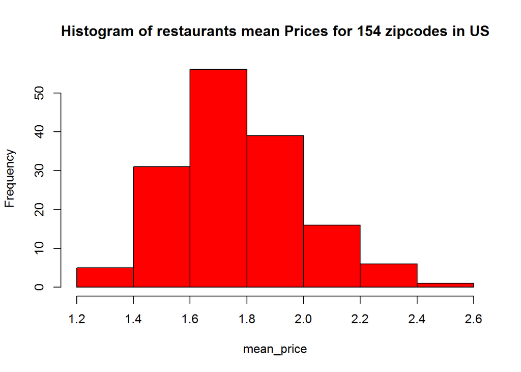

```r
hist(zip_credit$mean_price,xlab="mean_price",col = "red",main="Histogram of restaurants mean Prices for 154 zipcodes in US")
```

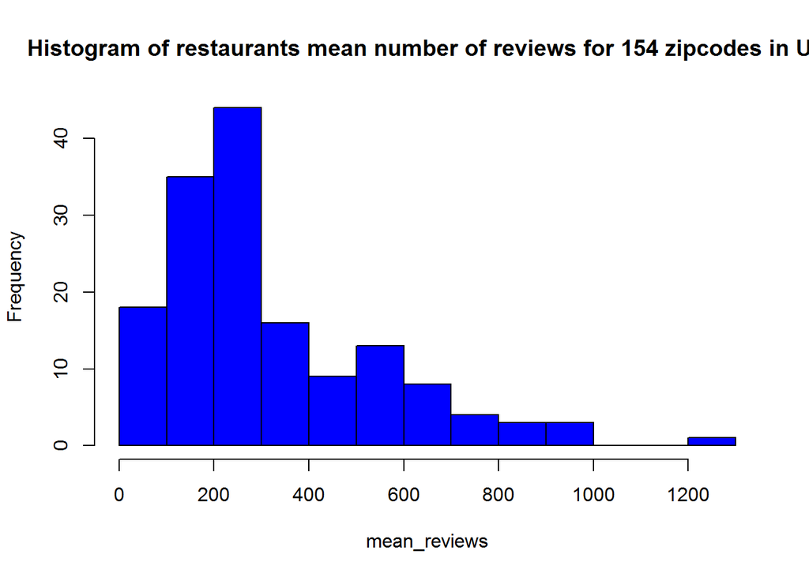

```r
hist(zip_credit$mean_reviews,xlab="mean_reviews",col = "blue",main="Histogram of restaurants mean number of reviews for 154 zipcodes in US")
```

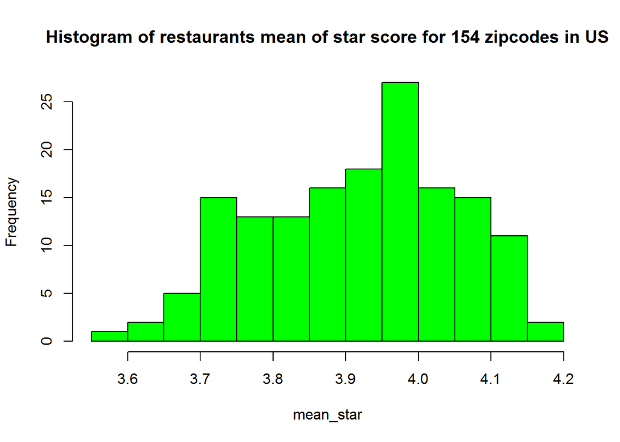

```r
hist(zip_credit$mean_star,xlab="mean_star",col = "green",main="Histogram of restaurants mean of star score for 154 zipcodes in US")
```

Regression Analysis:

In this section, we perform statistical and regression analysis to discover underlying significant linear relationhips between the independent variables:

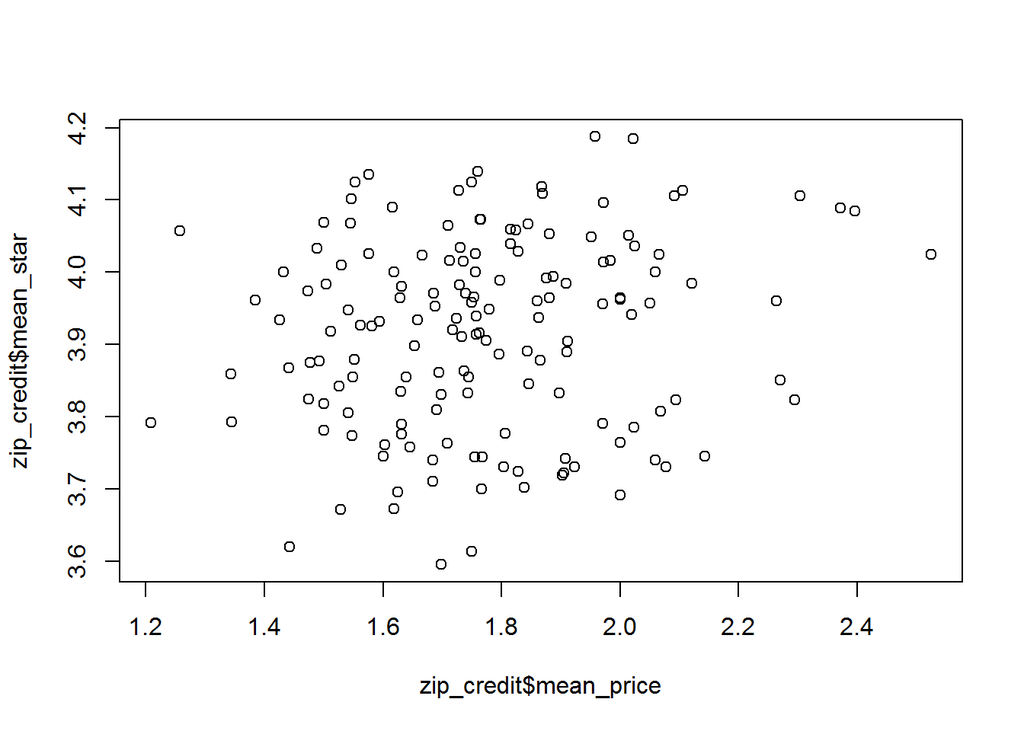

```r
########## plot star vs price ######################
plot(zip_credit$mean_price,zip_credit$mean_star)
```

```r
lm(mean_star~mean_price,data=zip_credit)  #Not significant
```

```
##
## Call:
## lm(formula = mean_star ~ mean_price, data = zip_credit)
##
## Coefficients:
## (Intercept)   mean_price
##     3.76119      0.08786
```

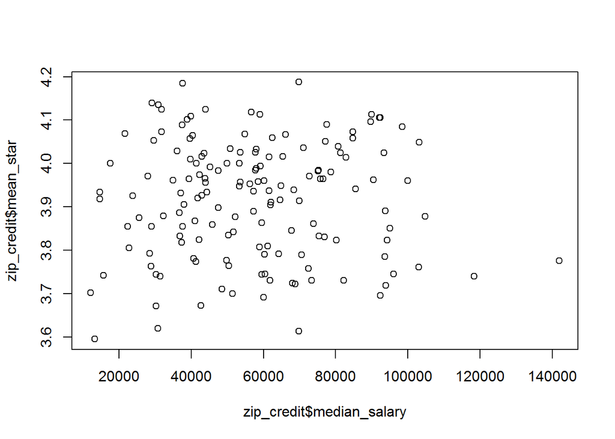

```r
plot(zip_credit$median_salary,zip_credit$mean_star)
```

```r
lm(mean_star~median_salary,data=zip_credit) # Not significant
```

```
##
## Call:
## lm(formula = mean_star ~ median_salary, data = zip_credit)
##
## Coefficients:
##   (Intercept)  median_salary
##     3.912e+00      8.865e-08
```

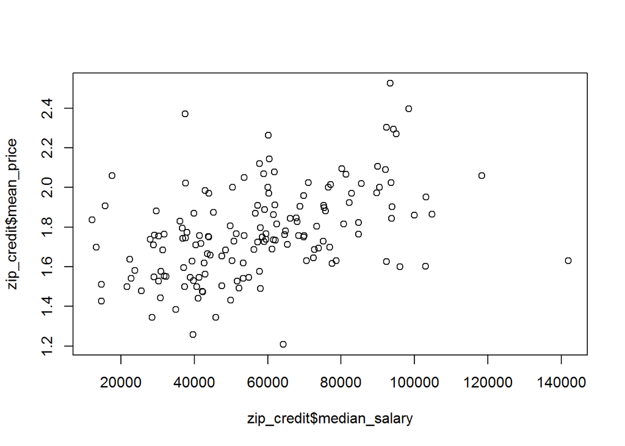

```r
plot(zip_credit$median_salary,zip_credit$mean_price)
```

```r
summary(lm(mean_price~median_salary,data=zip_credit)) #linear relation (positive slope)
```

```
##
## Call:
## lm(formula = mean_price ~ median_salary, data = zip_credit)
##
## Residuals:
##      Min       1Q   Median       3Q      Max
## -0.59297 -0.12427 -0.02076  0.10952  0.68549
##
## Coefficients:
##                Estimate Std. Error t value Pr(>|t|)
## (Intercept)   1.525e+00  4.354e-02  35.018  < 2e-16 ***
## median_salary 4.305e-06  7.014e-07   6.138 6.96e-09 ***
## ---
## Signif. codes:  0 '***' 0.001 '**' 0.01 '*' 0.05 '.' 0.1 ' ' 1
##
## Residual standard error: 0.2057 on 152 degrees of freedom
## Multiple R-squared:  0.1986, Adjusted R-squared:  0.1933
## F-statistic: 37.67 on 1 and 152 DF,  p-value: 6.961e-09
```

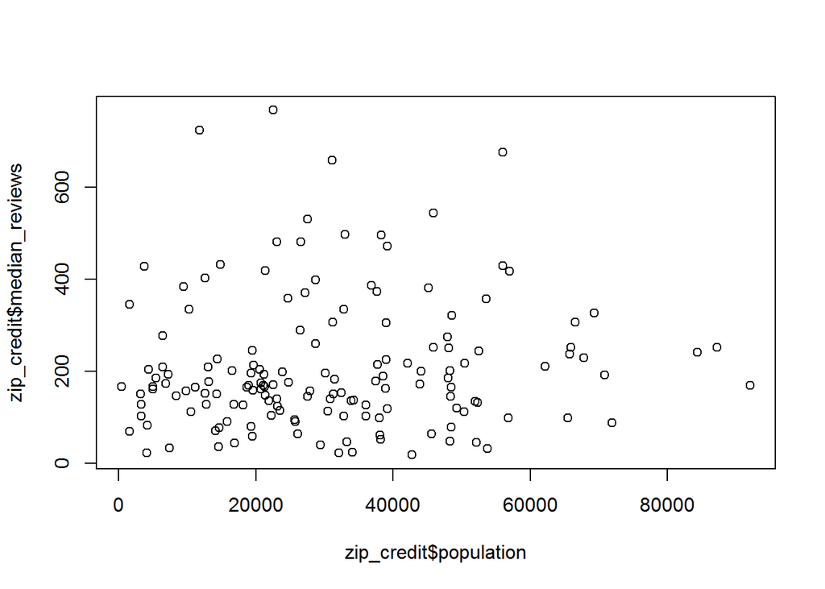

```r
plot(zip_credit$population,zip_credit$median_reviews)
```

```r
lm(median_reviews~population,data=zip_credit)# Not significant
```

```
##
## Call:
## lm(formula = median_reviews ~ population, data = zip_credit)
##
## Coefficients:
## (Intercept)   population
##   1.931e+02    5.451e-04
```

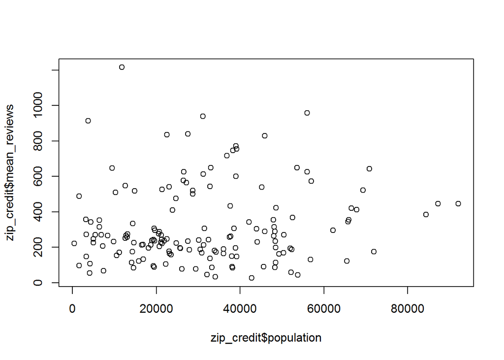

```r
plot(zip_credit$population,zip_credit$mean_reviews)
```

```r
lm(mean_reviews~population,data=zip_credit) #Not significant
```

```
##
## Call:
## lm(formula = mean_reviews ~ population, data = zip_credit)
##
## Coefficients:
## (Intercept)   population
##   2.773e+02    1.257e-03
```

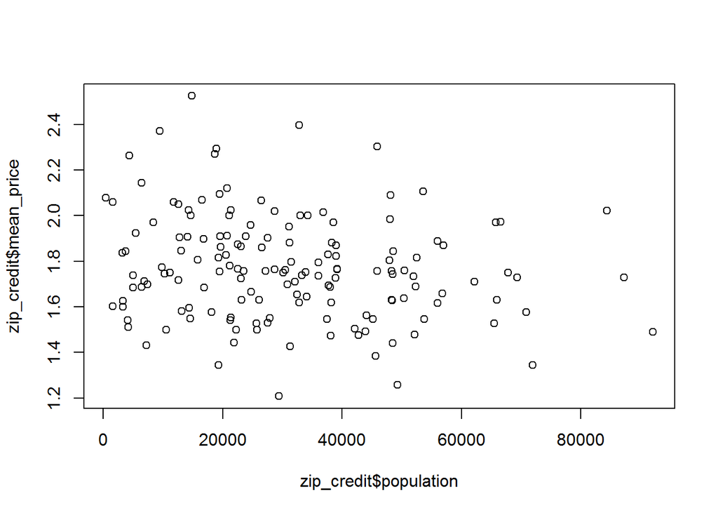

```r
plot(zip_credit$population,zip_credit$mean_price)
```

```r
summary(lm(mean_price~population,data=zip_credit)) #linear relationship ( negetive slope)
```

```
##
## Call:
## lm(formula = mean_price ~ population, data = zip_credit)
##
## Residuals:
##     Min      1Q  Median      3Q     Max
## -0.5667 -0.1478 -0.0118  0.1205  0.7170
##
## Coefficients:
##               Estimate Std. Error t value Pr(>|t|)
## (Intercept)  1.841e+00  3.466e-02  53.104   <2e-16 ***
## population  -2.235e-06  9.530e-07  -2.346   0.0203 *
## ---
## Signif. codes:  0 '***' 0.001 '**' 0.01 '*' 0.05 '.' 0.1 ' ' 1
##
## Residual standard error: 0.2257 on 152 degrees of freedom
## Multiple R-squared:  0.03493,    Adjusted R-squared:  0.02858
## F-statistic: 5.502 on 1 and 152 DF,  p-value: 0.02029
```

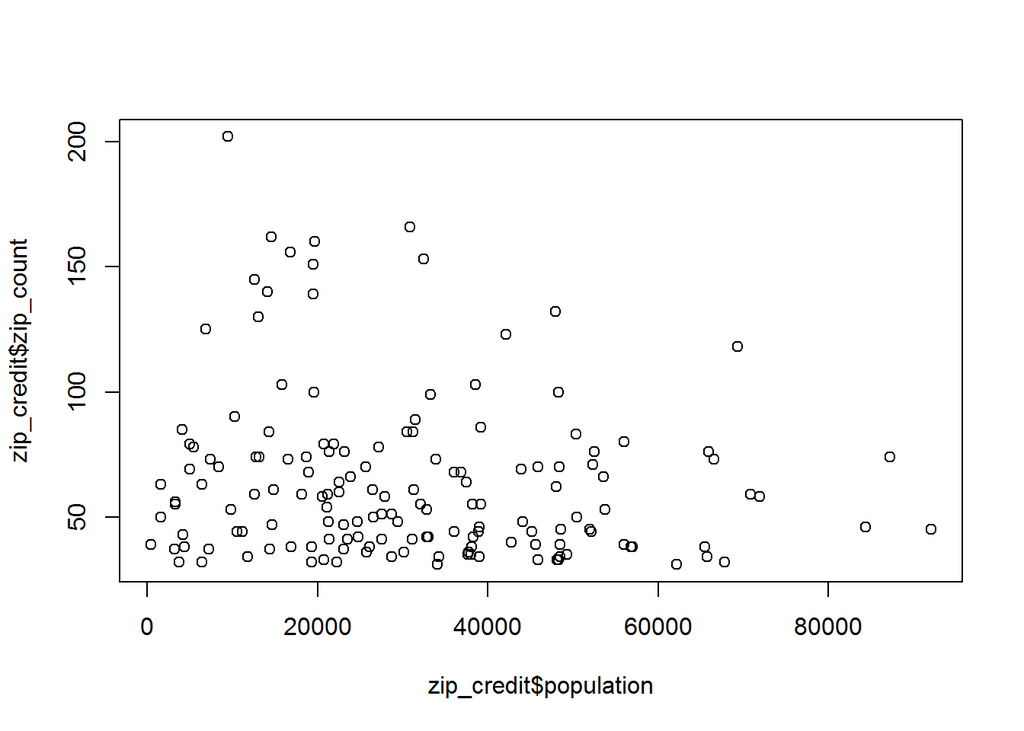

```r
plot(zip_credit$population,zip_credit$zip_count)
```

```r
summary(lm(zip_count~population,data=zip_credit)) #linear relationship ( negetive slope)  !!!
```

```
##
## Call:
## lm(formula = zip_count ~ population, data = zip_credit)
##
## Residuals:
##     Min      1Q  Median      3Q     Max
## -39.600 -22.796  -8.674  10.020 132.002
##
## Coefficients:
##               Estimate Std. Error t value Pr(>|t|)
## (Intercept) 72.6286405  5.0380164  14.416   <2e-16 ***
## population  -0.0002772  0.0001385  -2.001   0.0471 *
## ---
## Signif. codes:  0 '***' 0.001 '**' 0.01 '*' 0.05 '.' 0.1 ' ' 1
##
## Residual standard error: 32.81 on 152 degrees of freedom
## Multiple R-squared:  0.02568,    Adjusted R-squared:  0.01927
## F-statistic: 4.006 on 1 and 152 DF,  p-value: 0.04713
```

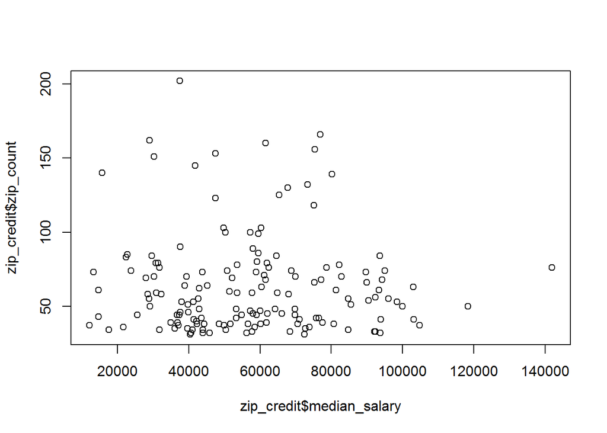

```r
plot(zip_credit$median_salary,zip_credit$zip_count)
```

```r
lm(zip_count~median_salary,data=zip_credit) #Not significant
```

```
##
## Call:
## lm(formula = zip_count ~ median_salary, data = zip_credit)
##
## Coefficients:
##   (Intercept)  median_salary
##     6.724e+01     -5.573e-05
```

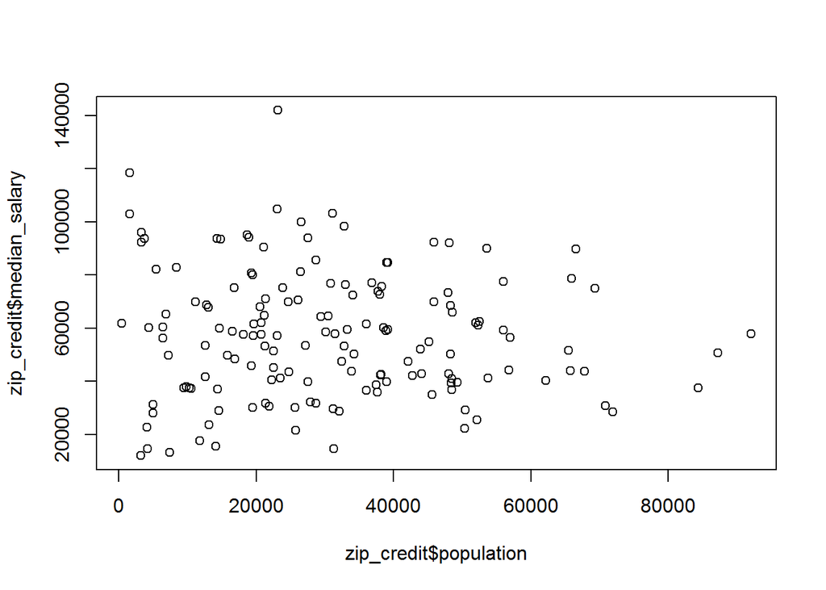

```r
plot(zip_credit$population,zip_credit$median_salary)
```

```r
lm(median_salary~population,data=zip_credit) #Not significant
```

```
##
## Call:
## lm(formula = median_salary ~ population, data = zip_credit)
##
## Coefficients:
## (Intercept)   population
##   6.012e+04   -8.813e-02
```

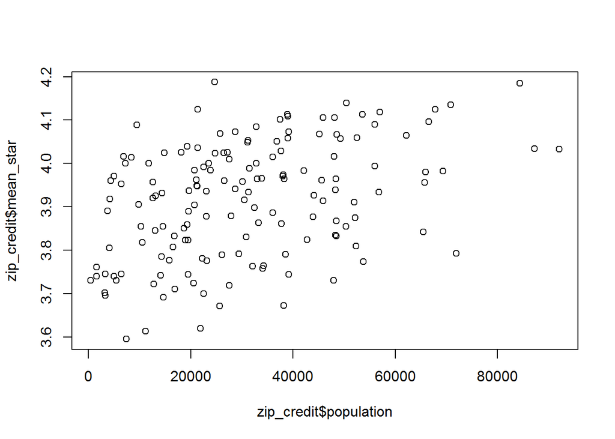

```r
plot(zip_credit$population,zip_credit$mean_star)
```

```r
summary(lm(mean_star~population,data=zip_credit))  # linear relationship (positive slope)
```

```
##
## Call:
## lm(formula = mean_star ~ population, data = zip_credit)
##
## Residuals:
##       Min        1Q    Median        3Q       Max
## -0.271099 -0.098320  0.005864  0.102580  0.288198
##
## Coefficients:
##              Estimate Std. Error t value Pr(>|t|)
## (Intercept) 3.830e+00  1.874e-02 204.337  < 2e-16 ***
## population  2.812e-06  5.152e-07   5.458 1.92e-07 ***
## ---
## Signif. codes:  0 '***' 0.001 '**' 0.01 '*' 0.05 '.' 0.1 ' ' 1
##
## Residual standard error: 0.1221 on 152 degrees of freedom
## Multiple R-squared:  0.1638, Adjusted R-squared:  0.1583
## F-statistic: 29.79 on 1 and 152 DF,  p-value: 1.92e-07
```

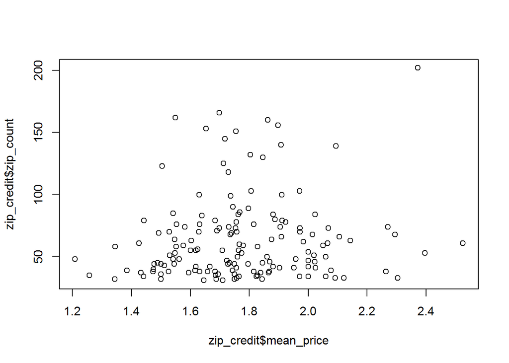

```r
plot(zip_credit$mean_price,zip_credit$zip_count)
```

```r
lm(zip_count~mean_price,data=zip_credit)  # Not significant
```

```
##
## Call:
## lm(formula = zip_count ~ mean_price, data = zip_credit)
##
## Coefficients:
## (Intercept)   mean_price
##       34.60        16.62
```

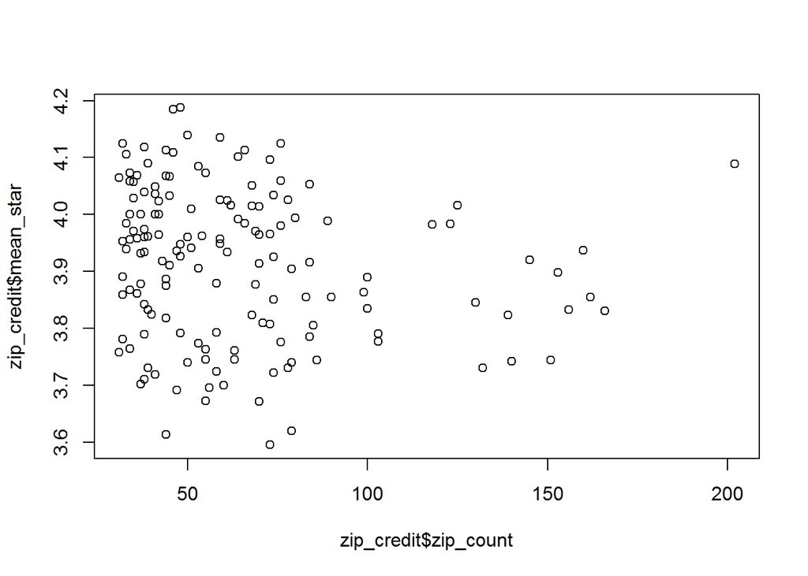

```r
plot(zip_credit$zip_count,zip_credit$mean_star)
```

```r
summary(lm(mean_star~zip_count,data=zip_credit)) #linear relationship (negetive slope)
```

```
##
## Call:
## lm(formula = mean_star ~ zip_count, data = zip_credit)
##
## Residuals:
##     Min      1Q  Median      3Q     Max
## -0.3166 -0.1018  0.0155  0.1034  0.2642
##
## Coefficients:
##               Estimate Std. Error t value Pr(>|t|)
## (Intercept)  3.9595407  0.0231456 171.071   <2e-16 ***
## zip_count   -0.0006665  0.0003212  -2.075   0.0397 *
## ---
## Signif. codes:  0 '***' 0.001 '**' 0.01 '*' 0.05 '.' 0.1 ' ' 1
##
## Residual standard error: 0.1316 on 152 degrees of freedom
## Multiple R-squared:  0.02755,    Adjusted R-squared:  0.02115
## F-statistic: 4.306 on 1 and 152 DF,  p-value: 0.03967
```

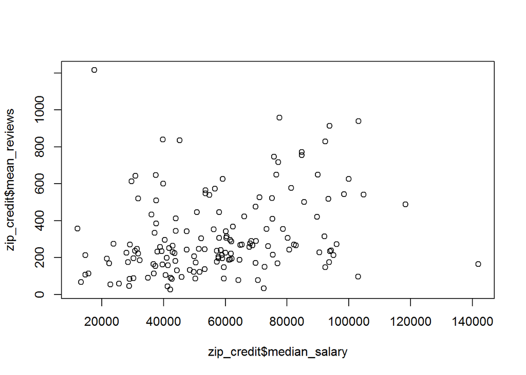

```r
plot(zip_credit$median_salary,zip_credit$mean_reviews)
```

```r
summary(lm(mean_reviews~median_salary,data=zip_credit)) #linear relationship (positive slope)
```

```
##
## Call:
## lm(formula = mean_reviews ~ median_salary, data = zip_credit)
##
## Residuals:
##    Min     1Q Median     3Q    Max
## -356.2 -138.9  -58.3  104.5  995.1
##
## Coefficients:
##                Estimate Std. Error t value Pr(>|t|)
## (Intercept)   1.774e+02  4.478e+01   3.961 0.000114 ***
## median_salary 2.420e-03  7.214e-04   3.354 0.001005 **
## ---
## Signif. codes:  0 '***' 0.001 '**' 0.01 '*' 0.05 '.' 0.1 ' ' 1
##
## Residual standard error: 211.6 on 152 degrees of freedom
## Multiple R-squared:  0.06891,    Adjusted R-squared:  0.06279
## F-statistic: 11.25 on 1 and 152 DF,  p-value: 0.001005
```

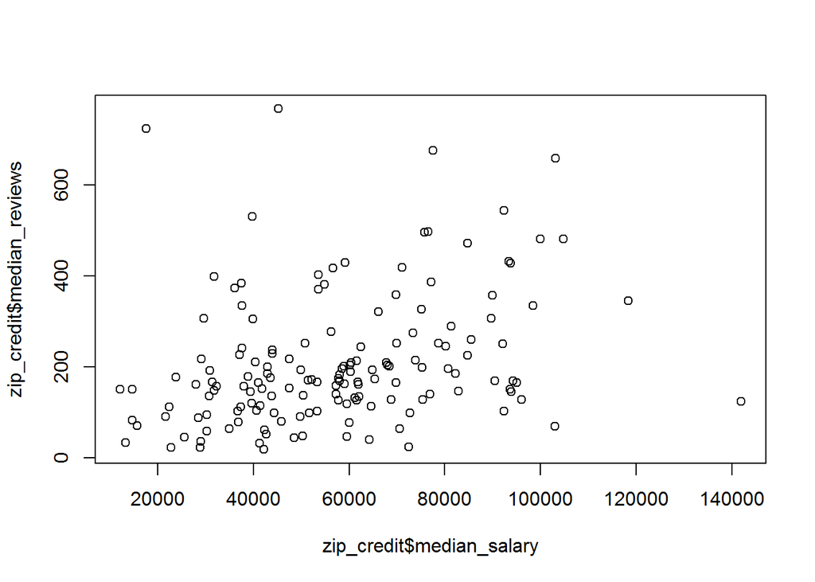

```r
plot(zip_credit$median_salary,zip_credit$median_reviews)
```

```r
summary(lm(median_reviews~median_salary,data=zip_credit)) #linear relationship (positive slope)
```

```
##
## Call:
## lm(formula = median_reviews ~ median_salary, data = zip_credit)
##
## Residuals:
##     Min      1Q  Median      3Q     Max
## -234.53  -93.37  -28.33   38.29  583.40
##
## Coefficients:
##                Estimate Std. Error t value Pr(>|t|)
## (Intercept)   1.084e+02  2.909e+01   3.727 0.000272 ***
## median_salary 1.769e-03  4.686e-04   3.776 0.000228 ***
## ---
## Signif. codes:  0 '***' 0.001 '**' 0.01 '*' 0.05 '.' 0.1 ' ' 1
##
## Residual standard error: 137.4 on 152 degrees of freedom
## Multiple R-squared:  0.08574,    Adjusted R-squared:  0.07973
## F-statistic: 14.25 on 1 and 152 DF,  p-value: 0.0002285
```

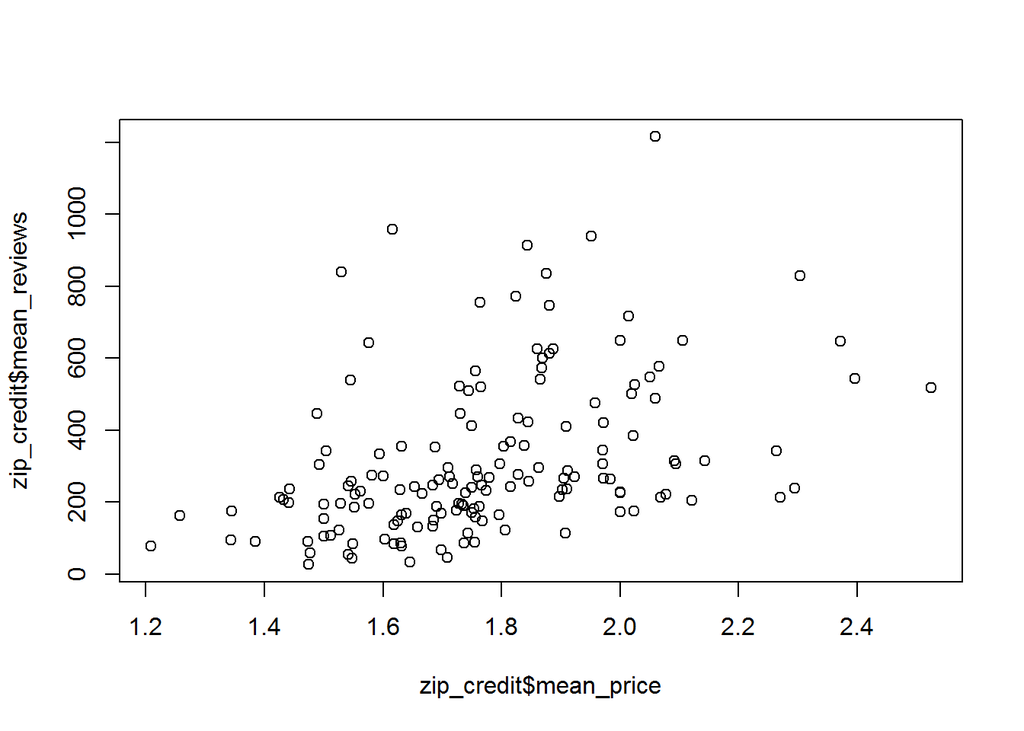

```r
plot(zip_credit$mean_price,zip_credit$mean_reviews)
```

```r
summary(lm(mean_reviews~mean_price,data=zip_credit)) #linear relationship (positive slope)
```

```
##
## Call:
## lm(formula = mean_reviews ~ mean_price, data = zip_credit)
##
## Residuals:
##     Min      1Q  Median      3Q     Max
## -301.68 -133.57  -47.67   83.00  784.83
##
## Coefficients:
##             Estimate Std. Error t value Pr(>|t|)
## (Intercept)  -387.46     125.70  -3.083  0.00244 **
## mean_price    397.21      70.37   5.645 7.89e-08 ***
## ---
## Signif. codes:  0 '***' 0.001 '**' 0.01 '*' 0.05 '.' 0.1 ' ' 1
##
## Residual standard error: 199.4 on 152 degrees of freedom
## Multiple R-squared:  0.1733, Adjusted R-squared:  0.1679
## F-statistic: 31.86 on 1 and 152 DF,  p-value: 7.887e-08
```

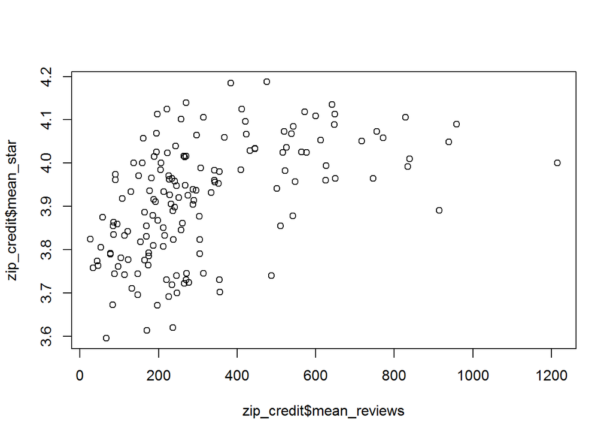

```r
plot(zip_credit$mean_reviews,zip_credit$mean_star)
```

```r
summary(lm(mean_star~mean_reviews,data=zip_credit)) #linear relationship (positive slope)
```

```
##
## Call:
## lm(formula = mean_star ~ mean_reviews, data = zip_credit)
##
## Residuals:
##      Min       1Q   Median       3Q      Max
## -0.27200 -0.07100  0.01034  0.07619  0.24710
##
## Coefficients:
##               Estimate Std. Error t value Pr(>|t|)
## (Intercept)  3.819e+00  1.633e-02  233.82  < 2e-16 ***
## mean_reviews 3.092e-04  4.253e-05    7.27 1.77e-11 ***
## ---
## Signif. codes:  0 '***' 0.001 '**' 0.01 '*' 0.05 '.' 0.1 ' ' 1
##
## Residual standard error: 0.115 on 152 degrees of freedom
## Multiple R-squared:  0.258,  Adjusted R-squared:  0.2531
## F-statistic: 52.85 on 1 and 152 DF,  p-value: 1.771e-11
```

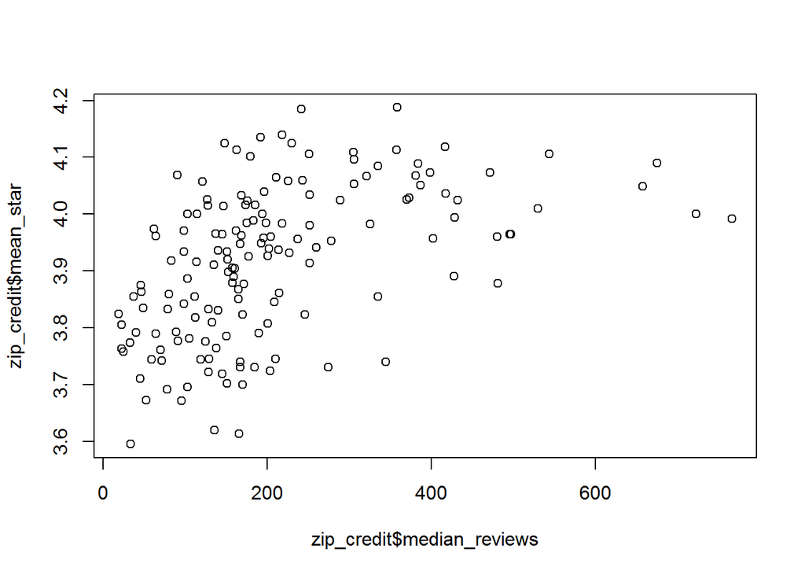

```r
plot(zip_credit$median_reviews,zip_credit$mean_star)
```

```r
summary(lm(mean_star~median_reviews,data=zip_credit)) #linear relationship (positive slope)
```

```
##
## Call:
## lm(formula = mean_star ~ median_reviews, data = zip_credit)
##
## Residuals:
##      Min       1Q   Median       3Q      Max
## -0.28327 -0.08167  0.01140  0.08339  0.25339
##
## Coefficients:
##                 Estimate Std. Error t value Pr(>|t|)
## (Intercept)    3.822e+00  1.669e-02 229.006  < 2e-16 ***
## median_reviews 4.537e-04  6.572e-05   6.904 1.29e-10 ***
## ---
## Signif. codes:  0 '***' 0.001 '**' 0.01 '*' 0.05 '.' 0.1 ' ' 1
##
## Residual standard error: 0.1165 on 152 degrees of freedom
## Multiple R-squared:  0.2387, Adjusted R-squared:  0.2337
## F-statistic: 47.66 on 1 and 152 DF,  p-value: 1.29e-10
```

```r
###################################################
```

We can summerize these relationships in the following figure:

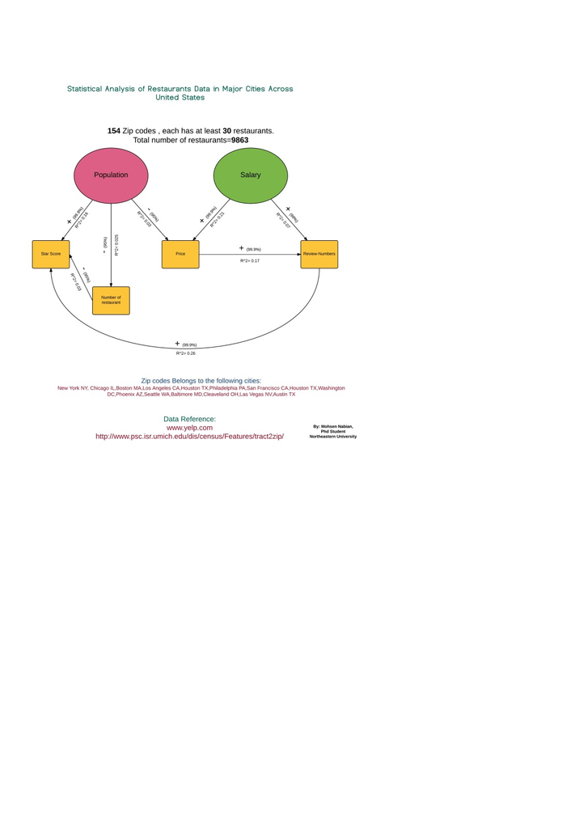